# Data Wrangling (Data Preprocessing)

Practical assessment 2

Jeremy Jian Zhi Chia

25/09/2021

## **Setup**

```r
# Load necessary packages
library(kableExtra)
library(magrittr)
library(dplyr)
library(tidyr)
library(readr)
library(readxl)
library(openxlsx)
library(ggplot2)
library(tools)
library(forecast)
```

## **Student names, numbers and percentage of contributions**

Group information

| Student name | Student number | Percentage of contribution |
| --- | --- | --- |
| Jeremy Jian Zhi Chia | s3917515 | 100% |

## **Executive Summary**

- Datasets of Median House Prices and Criminal Incidents by Suburb and LGA are loaded into the workspace. After loading the datasets, they are formatted to a desired format by fixing column headers to allow for joining/merging of datasets. The dataset is also filtered to only display data from the year 2020.
- After the joining of datasets, the process of tidying & manipulating is done by grouping the dataset by the selected variables to retrieve the total crime count within each LGA. After the creation of a new variable, it is then joined with the main dataset.
- By understanding the dataset, the various attributes and structure of the dataset were converted to their most accurate data types that will aid in future analysis. Columns that are considered redundant are removed in this step.
- The section of the data that do not conform to tidy data rules are fixed to ensure that each variable has its own column and values are recorded within rows. Variables that are supposed to be values are dealt with in an appropriate manner. As the dataset only included criminal incidents for suburbs by year, the dataset is mutated to include a new variable that displays the average criminal incidents count per quarter of the year. New variables created are converted to their rightful data structures.
- The dataset is scanned for missing values. It was determined that the missing values were caused by the lack of information/data within the Criminal Incidents by Suburb and LGA dataset. Thus, causing some suburbs to not have crime data. The decision was made to drop all the rows of missing values which make up a proportion of 1.38% of the entire dataset.
- As the distribution between the variables being investigated are bivariate, a scatterplot is used to determine the scale of possible outliers within the dataset. The scale of possible outliers and distribution of univariate outliers were also investigated here. A decision to maintain all rows was made as these possible outliers were not caused by any form of error and is critical for future analysis.
- The distributions of the quantitative variables were inspected and proper transformation techniques were applied to achieve symmetrical distributions. Various transformation techniques were used and the one that worked best was chosen to transform the skewed distribution.

## **Data**

Source 1:

- Data Vic (https://discover.data.vic.gov.au/dataset/victorian-property-sales-report-median-house-by-suburb)

Description:

- This dataset lists the percentage shift in median prices between quarters as well as the change over a 12-month period for Victorian houses.

Variables:

- Suburb - All suburbs in Victoria, Australia
- Jul-Sep 19 - Median house prices for that period
- Oct-Dec 19 - Median house prices for that period
- Jan-Mar 20 - Median house prices for that period
- Apr-Jun 20 - Median house prices for that period
- Jul-Sep 20 - Median house prices for that period
- No of Sales Jul-Sep 20 - Number of house sales for that period
- No of Sales YTD - Year to date number of house sales
- Change % Jul-Sep 19 Jul-Sep 19 - Percentage change in median house price between two periods
- Change % Apr-Jun 20 Jul-Sep 20 - Percentage change in median house price between two periods

Source 2: * Crime Statistics Agency (https://www.crimestatistics.vic.gov.au/crime-statistics/historical-crime-data/download-data-3)

Description:

- There are five tables within this excel workbook. The dataset of interest chosen is:
- Criminal Incidents by principal offence, local government area and postcode or suburb/town

Variables:

- Year - Displays the year when the crime was committed/recorded
- Year ending - The month when a full year is recorded (September for this dataset)
- Local Government Area - The LGA where the crime was committed/recorded
- Postcode - The postcode of the suburb where the crime was committed/recorded
- Suburb/Town Name - The suburb where the crime was committed/recorded
- Offence Division - General category of the crime committed/recorded
- Offence Subdivision - Offence division specific category of crime committed/recorded
- Offence Subgroup - Subgroup of crime committed/recorded (Finest granularity of crime category)
- Incidents Recorded - Number of crimes recorded

```r
# Import the data, provide your R codes here.

# House median prices dataset
house_medians <- read_excel("data/House_Medians3rdQtr2020.xls", skip = 1)

# Crime rate by principal offence, LGA and police service area dataset
crime_rate <- read_excel("data/Data_Tables_LGA_Criminal_Incidents_Year_Ending_September_2020.xlsx%3F8rMGzuMnVt5oC9mV_AAn_dmq1tfyPo9T=.xlsx",
    sheet = "Table 02")

# Criminal incidents by LGA and suburb dataset
criminal_incidents_lga_suburb <- read_excel("data/Data_Tables_LGA_Criminal_Incidents_Year_Ending_September_2020.xlsx%3F8rMGzuMnVt5oC9mV_AAn_dmq1tfyPo9T=.xlsx",
    sheet = "Table 03")
```

```r
# Creating a dataframe of suburbs and their respective LGAs
suburb_lga <- criminal_incidents_lga_suburb %>% select(`Suburb/Town Name`, `Local Government Area`) %>% unique
suburb_lga %>% head(10)
```

| Suburb/Town Name | Local Government Area |
| --- | --- |
| Dederang | Alpine |
| Glen Creek | Alpine |
| Gundowring | Alpine |
| Kergunyah South | Alpine |
| Mongans Bridge | Alpine |
| Upper Gundowring | Alpine |
| Tawonga | Alpine |
| Tawonga South | Alpine |
| Mount Beauty | Alpine |
| Barwidgee | Alpine |

A dataframe of each suburbs and their corresponding LGAs are created using the criminal incidents by LGA and suburb dataset. This allows for identifying which LGA a particular suburb belong to.

```r
# Lowering and capitalising suburb names in House Median Prices dataset
house_medians$SUBURB <- house_medians$SUBURB %>% tolower() %>% tools::toTitleCase()
house_medians$SUBURB %>% head(10)
```

```
 [1] "Abbotsford"   "Aberfeldie"   "Aintree"      "Aireys Inlet" "Airport West" "Albanvale"    "Albert Park"  "Albion"
 [9] "Alexandra"    "Alfredton"
```

To allow for joining of the house median prices dataset with the Suburb-LGA dataset created above, the values of each containing the suburb names must match between the datasets. Therefore, they are converted from all uppercase to lowercase and title case.

```r
# Joining suburb and LGA dataframe with house median prices
house_medians <- house_medians %>% left_join(suburb_lga, by=c("SUBURB" = "Suburb/Town Name"))

# Rearranging variables within dataframe
house_medians <- house_medians[,c("SUBURB", "Local Government Area", "Jul - Sep 19", "Oct - Dec 19", "Jan - Mar 20", "Apr- Jun 20", "Jul - Sep 20", "No of sales Jul - Sep 20", "No of Sales YTD", "Change % Jul - Sep 19 Jul - Sep 20", "Change % Apr - Jun 20 Jul - Sep 20")]

house_medians %>% head(10)
```

| SUBURB | Local Government Area | Jul - Sep 19 | Oct - Dec 19 | Jan - Mar 20 | Apr- Jun 20 | Jul - Sep 20 | No of sales Jul - Sep 20 | No of Sales YTD | Change % Jul - Sep 19 Jul - Sep 20 | Change % Apr - Jun 20 Jul - Sep 20 |
| --- | --- | --- | --- | --- | --- | --- | --- | --- | --- | --- |
| Abbotsford | Yarra | 1160000 | 1027500 | 1230000 | 1080000 | 1260000 | 8 | 33 | 8.6 | 16.7 |
| Aberfeldie | Moonee Valley | 1352500 | 1650000 | 1732500 | 1375000 | 1600000 | 6 | 25 | 18.3 | 16.4 |
| Aintree | NA | 575000 | 620400 | 675000 | 685000 | 740000 | 8 | 52 | 28.7 | 8.0 |
| Aireys Inlet | Surf Coast | 700000 | 1400000 | 1050000 | 1010000 | 1300000 | 7 | 19 | 85.7 | 28.7 |
| Airport West | Moonee Valley | 810500 | 851000 | 832500 | 798500 | 775000 | 15 | 69 | -4.4 | -2.9 |
| Albanvale | Brimbank | 500000 | 517000 | 551500 | 505000 | 505000 | 11 | 34 | 1.0 | 0.0 |
| Albert Park | Port Phillip | 2465000 | 2220000 | 2040000 | 1777500 | 1738800 | 8 | 57 | -29.5 | -2.2 |
| Albion | Brimbank | 600000 | 737500 | 765000 | 571000 | 755000 | 3 | 12 | 25.8 | 32.2 |
| Alexandra | Murrindindi | 285000 | 325000 | 388500 | 395000 | 340000 | 13 | 42 | 19.3 | -13.9 |
| Alfredton | Ballarat | 498000 | 485100 | 500000 | 500000 | 510000 | 67 | 162 | 2.4 | 2.0 |

The house median prices dataset and the suburb-LGA dataset are joined together. They are rearranged so that the Suburb and LGA columns are side-to-side.

```r
# Filter by year
criminal_incidents_lga_suburb <- criminal_incidents_lga_suburb %>% filter(Year == "2020")

# View filtered values of year column
criminal_incidents_lga_suburb$Year %>% unique()
```

```
[1] 2020
```

The crime incidents dataset reports crime incidents for the year ending September 2020. Thus, the time frame for one year from October 2019 to September 2020. As the time frame of interest for this project is only for the year ending Sept 2020, the dataset is filtered to only display the crimes that are committed in the year 2020.

## **Tidy & Manipulate Data II**

```r
# Groupby and count "Offence Division"
offence_division_count <- criminal_incidents_lga_suburb %>% group_by(`Suburb/Town Name`, Postcode, `Local Government Area`) %>% count(`Offence Division`)

# Renaming newly created column
names(offence_division_count)[names(offence_division_count) == "n"] <- "Total Offence Division Count (Year)"

offence_division_count %>% head
```

| Suburb/Town Name | Postcode | Local Government Area | Offence Division | Total Offence Division Count (Year) |
| --- | --- | --- | --- | --- |
| Abbotsford | 3067 | Yarra | A Crimes against the person | 13 |
| Abbotsford | 3067 | Yarra | B Property and deception offences | 16 |
| Abbotsford | 3067 | Yarra | C Drug offences | 5 |
| Abbotsford | 3067 | Yarra | D Public order and security offences | 9 |
| Abbotsford | 3067 | Yarra | E Justice procedures offences | 6 |
| Abbotsford | 3067 | Yarra | F Other offences | 2 |

The initial dataset of criminal incidents by LGA and suburb show the count of various types of offence divisions, offence subdivisions and offence subgroups in fine granularity. Assuming we are only interested in the broader offence division without accounting for offence subdivisions and offence subgroups in each suburb for the year 2020, a new column of “Offence Division Count” is created to display the count of general offence divisions committed in each suburb in 2020.

```r
# Joining house median prices with criminal incidents by LGA and Suburb
house_medians_criminal_incidents <- house_medians %>% left_join(offence_division_count, by=c("SUBURB" = "Suburb/Town Name", "Local Government Area"))

house_medians_criminal_incidents %>% head()
```

| SUBURB | Local Government Area | Jul - Sep 19 | Oct - Dec 19 | Jan - Mar 20 | Apr- Jun 20 | Jul - Sep 20 | No of sales Jul - Sep 20 | No of Sales YTD | Change % Jul - Sep 19 Jul - Sep 20 | Change % Apr - Jun 20 Jul - Sep 20 | Postcode | Offence Division | Total Offence Division Count (Year) |
| --- | --- | --- | --- | --- | --- | --- | --- | --- | --- | --- | --- | --- | --- |
| Abbotsford | Yarra | 1160000 | 1027500 | 1230000 | 1080000 | 1260000 | 8 | 33 | 8.6 | 16.7 | 3067 | A Crimes against the person | 13 |
| Abbotsford | Yarra | 1160000 | 1027500 | 1230000 | 1080000 | 1260000 | 8 | 33 | 8.6 | 16.7 | 3067 | B Property and deception offences | 16 |
| Abbotsford | Yarra | 1160000 | 1027500 | 1230000 | 1080000 | 1260000 | 8 | 33 | 8.6 | 16.7 | 3067 | C Drug offences | 5 |
| Abbotsford | Yarra | 1160000 | 1027500 | 1230000 | 1080000 | 1260000 | 8 | 33 | 8.6 | 16.7 | 3067 | D Public order and security offences | 9 |
| Abbotsford | Yarra | 1160000 | 1027500 | 1230000 | 1080000 | 1260000 | 8 | 33 | 8.6 | 16.7 | 3067 | E Justice procedures offences | 6 |
| Abbotsford | Yarra | 1160000 | 1027500 | 1230000 | 1080000 | 1260000 | 8 | 33 | 8.6 | 16.7 | 3067 | F Other offences | 2 |

The house median prices and suburb-LGA datasets are then joined with the criminal incidents by suburb/LGA dataset which shows the count of various types of offences that occurred within that suburb in 2020.

## **Understand**

```r
# Renaming of columns
names(house_medians_criminal_incidents)[names(house_medians_criminal_incidents) == "SUBURB"] <- "Suburb"

# Checking new column names
house_medians_criminal_incidents %>% colnames()
```

```
 [1] "Suburb"                              "Local Government Area"               "Jul - Sep 19"
 [4] "Oct - Dec 19"                        "Jan - Mar 20"                        "Apr- Jun 20"
 [7] "Jul - Sep 20"                        "No of sales Jul - Sep 20"            "No of Sales YTD"
[10] "Change % Jul - Sep 19 Jul - Sep 20"  "Change % Apr - Jun 20 Jul - Sep 20"  "Postcode"
[13] "Offence Division"                    "Total Offence Division Count (Year)"
```

```r
# Inspect structure of dataset
house_medians_criminal_incidents %>% str()
```

```
tibble [4,340 x 14] (S3: tbl_df/tbl/data.frame)
 $ Suburb                             : chr [1:4340] "Abbotsford" "Abbotsford" "Abbotsford" "Abbotsford" ...
 $ Local Government Area              : chr [1:4340] "Yarra" "Yarra" "Yarra" "Yarra" ...
 $ Jul - Sep 19                       : chr [1:4340] "1160000" "1160000" "1160000" "1160000" ...
 $ Oct - Dec 19                       : chr [1:4340] "1027500" "1027500" "1027500" "1027500" ...
 $ Jan - Mar 20                       : chr [1:4340] "1230000" "1230000" "1230000" "1230000" ...
 $ Apr- Jun 20                        : chr [1:4340] "1080000" "1080000" "1080000" "1080000" ...
 $ Jul - Sep 20                       : chr [1:4340] "1260000" "1260000" "1260000" "1260000" ...
 $ No of sales Jul - Sep 20           : num [1:4340] 8 8 8 8 8 8 6 6 6 6 ...
 $ No of Sales YTD                    : chr [1:4340] "33" "33" "33" "33" ...
 $ Change % Jul - Sep 19 Jul - Sep 20 : chr [1:4340] "8.6" "8.6" "8.6" "8.6" ...
 $ Change % Apr - Jun 20 Jul - Sep 20 : chr [1:4340] "16.7" "16.7" "16.7" "16.7" ...
 $ Postcode                           : num [1:4340] 3067 3067 3067 3067 3067 ...
 $ Offence Division                   : chr [1:4340] "A Crimes against the person" "B Property and deception offences" "C Drug offences" "D Public order and security offences" ...
 $ Total Offence Division Count (Year): int [1:4340] 13 16 5 9 6 2 6 9 2 2 ...
```

Upon inspecting the structure of the dataset, there are some obvious mistakes in classifying the data types of the variables. Some of the variables such as median house prices over specific periods should be stored as numerics instead of characters. Furthermore, certain variables such as suburb, LGA, postcode should be stored as factors as they can be deemed as data that can be categorised.

```r
# Converting the data structures of variables

# Storing supposed numeric columns as an object
numeric_cols <- c("Jul - Sep 19", "Oct - Dec 19", "Jan - Mar 20", "Apr- Jun 20", "Jul - Sep 20", "No of Sales YTD", "Change % Jul - Sep 19 Jul - Sep 20", "Change % Apr - Jun 20 Jul - Sep 20")

# Converting characters to numeric data types
house_medians_criminal_incidents[numeric_cols] <- lapply(house_medians_criminal_incidents[numeric_cols], as.numeric)
# Checking structure after conversion
house_medians_criminal_incidents %>% str()
```

```
tibble [4,340 x 14] (S3: tbl_df/tbl/data.frame)
 $ Suburb                             : chr [1:4340] "Abbotsford" "Abbotsford" "Abbotsford" "Abbotsford" ...
 $ Local Government Area              : chr [1:4340] "Yarra" "Yarra" "Yarra" "Yarra" ...
 $ Jul - Sep 19                       : num [1:4340] 1160000 1160000 1160000 1160000 1160000 ...
 $ Oct - Dec 19                       : num [1:4340] 1027500 1027500 1027500 1027500 1027500 ...
 $ Jan - Mar 20                       : num [1:4340] 1230000 1230000 1230000 1230000 1230000 ...
 $ Apr- Jun 20                        : num [1:4340] 1080000 1080000 1080000 1080000 1080000 ...
 $ Jul - Sep 20                       : num [1:4340] 1260000 1260000 1260000 1260000 1260000 1260000 1600000 1600000 1600000 1600000 ...
 $ No of sales Jul - Sep 20           : num [1:4340] 8 8 8 8 8 8 6 6 6 6 ...
 $ No of Sales YTD                    : num [1:4340] 33 33 33 33 33 33 25 25 25 25 ...
 $ Change % Jul - Sep 19 Jul - Sep 20 : num [1:4340] 8.6 8.6 8.6 8.6 8.6 8.6 18.3 18.3 18.3 18.3 ...
 $ Change % Apr - Jun 20 Jul - Sep 20 : num [1:4340] 16.7 16.7 16.7 16.7 16.7 16.7 16.4 16.4 16.4 16.4 ...
 $ Postcode                           : num [1:4340] 3067 3067 3067 3067 3067 ...
 $ Offence Division                   : chr [1:4340] "A Crimes against the person" "B Property and deception offences" "C Drug offences" "D Public order and security offences" ...
 $ Total Offence Division Count (Year): int [1:4340] 13 16 5 9 6 2 6 9 2 2 ...
```

```r
# Storing supposed factor columns as an object
fac_cols <- c("Suburb", "Local Government Area", "Postcode", "Offence Division")

# Converting characters to factors
house_medians_criminal_incidents[fac_cols] <- lapply(house_medians_criminal_incidents[fac_cols], as.factor)

# View structure
house_medians_criminal_incidents %>% str()
```

```
tibble [4,340 x 14] (S3: tbl_df/tbl/data.frame)
 $ Suburb                             : Factor w/ 761 levels "Abbotsford","Aberfeldie",..: 1 1 1 1 1 1 2 2 2 2 ...
 $ Local Government Area              : Factor w/ 79 levels "Alpine","Ararat",..: 77 77 77 77 77 77 50 50 50 50 ...
 $ Jul - Sep 19                       : num [1:4340] 1160000 1160000 1160000 1160000 1160000 ...
 $ Oct - Dec 19                       : num [1:4340] 1027500 1027500 1027500 1027500 1027500 ...
 $ Jan - Mar 20                       : num [1:4340] 1230000 1230000 1230000 1230000 1230000 ...
 $ Apr- Jun 20                        : num [1:4340] 1080000 1080000 1080000 1080000 1080000 ...
 $ Jul - Sep 20                       : num [1:4340] 1260000 1260000 1260000 1260000 1260000 1260000 1600000 1600000 1600000 1600000 ...
 $ No of sales Jul - Sep 20           : num [1:4340] 8 8 8 8 8 8 6 6 6 6 ...
 $ No of Sales YTD                    : num [1:4340] 33 33 33 33 33 33 25 25 25 25 ...
 $ Change % Jul - Sep 19 Jul - Sep 20 : num [1:4340] 8.6 8.6 8.6 8.6 8.6 8.6 18.3 18.3 18.3 18.3 ...
 $ Change % Apr - Jun 20 Jul - Sep 20 : num [1:4340] 16.7 16.7 16.7 16.7 16.7 16.7 16.4 16.4 16.4 16.4 ...
 $ Postcode                           : Factor w/ 453 levels "3002","3003",..: 53 53 53 53 53 53 29 29 29 29 ...
 $ Offence Division                   : Factor w/ 6 levels "A Crimes against the person",..: 1 2 3 4 5 6 1 2 3 4 ...
 $ Total Offence Division Count (Year): int [1:4340] 13 16 5 9 6 2 6 9 2 2 ...
```

The output above displays the structure of the dataframe after conversion of various data types. Categorical variables are converted to factors to allow further analysis to be done on any given factor. There are no ordered factors. Numerical variables that are previously character variables are treated and converted to the numerical data type.

```r
# Rearranging variables within dataframe
house_medians_criminal_incidents <- house_medians_criminal_incidents[,c("Suburb", "Postcode", "Local Government Area", "Jul - Sep 19", "Oct - Dec 19", "Jan - Mar 20", "Apr- Jun 20", "Jul - Sep 20", "No of sales Jul - Sep 20", "No of Sales YTD", "Change % Jul - Sep 19 Jul - Sep 20", "Change % Apr - Jun 20 Jul - Sep 20", "Offence Division", "Total Offence Division Count (Year)")]

# View dataframe
house_medians_criminal_incidents %>% head()
```

| Suburb | Postcode | Local Government Area | Jul - Sep 19 | Oct - Dec 19 | Jan - Mar 20 | Apr- Jun 20 | Jul - Sep 20 | No of sales Jul - Sep 20 | No of Sales YTD | Change % Jul - Sep 19 Jul - Sep 20 | Change % Apr - Jun 20 Jul - Sep 20 | Offence Division | Total Offence Division Count (Year) |
| --- | --- | --- | --- | --- | --- | --- | --- | --- | --- | --- | --- | --- | --- |
| Abbotsford | 3067 | Yarra | 1160000 | 1027500 | 1230000 | 1080000 | 1260000 | 8 | 33 | 8.6 | 16.7 | A Crimes against the person | 13 |
| Abbotsford | 3067 | Yarra | 1160000 | 1027500 | 1230000 | 1080000 | 1260000 | 8 | 33 | 8.6 | 16.7 | B Property and deception offences | 16 |
| Abbotsford | 3067 | Yarra | 1160000 | 1027500 | 1230000 | 1080000 | 1260000 | 8 | 33 | 8.6 | 16.7 | C Drug offences | 5 |
| Abbotsford | 3067 | Yarra | 1160000 | 1027500 | 1230000 | 1080000 | 1260000 | 8 | 33 | 8.6 | 16.7 | D Public order and security offences | 9 |
| Abbotsford | 3067 | Yarra | 1160000 | 1027500 | 1230000 | 1080000 | 1260000 | 8 | 33 | 8.6 | 16.7 | E Justice procedures offences | 6 |
| Abbotsford | 3067 | Yarra | 1160000 | 1027500 | 1230000 | 1080000 | 1260000 | 8 | 33 | 8.6 | 16.7 | F Other offences | 2 |

The above output displays the rearranged columns of the dataframe. Suburb, postcode and LGA and rearranged to be side-by-side to allow for identification of suburbs and their corresponding postcodes and LGAs.

## **Tidy & Manipulate Data I**

```r
# Display section of untidy data
house_medians_criminal_incidents %>% select("Jul - Sep 19", "Oct - Dec 19", "Jan - Mar 20", "Apr- Jun 20", "Jul - Sep 20")
```

| Jul - Sep 19 | Oct - Dec 19 | Jan - Mar 20 | Apr- Jun 20 | Jul - Sep 20 |
| --- | --- | --- | --- | --- |
| 1160000 | 1027500 | 1230000 | 1080000 | 1260000 |
| 1160000 | 1027500 | 1230000 | 1080000 | 1260000 |
| 1160000 | 1027500 | 1230000 | 1080000 | 1260000 |
| 1160000 | 1027500 | 1230000 | 1080000 | 1260000 |
| 1160000 | 1027500 | 1230000 | 1080000 | 1260000 |
| 1160000 | 1027500 | 1230000 | 1080000 | 1260000 |
| 1352500 | 1650000 | 1732500 | 1375000 | 1600000 |
| 1352500 | 1650000 | 1732500 | 1375000 | 1600000 |
| 1352500 | 1650000 | 1732500 | 1375000 | 1600000 |
| 1352500 | 1650000 | 1732500 | 1375000 | 1600000 |

[output cut: 990 more lines]

The above output displays portion of the data that do not conform to the tidy data rules. They are the median house prices of multiple quarters within the years 2019 and 2020. These quarters are stored as variables. However, they represent the values of annually quarters.

```r
# Transform data
house_medians_criminal_incidents <- house_medians_criminal_incidents %>% pivot_longer(names_to = "Quarter / Year", values_to = "Median Price", cols = c("Jul - Sep 19", "Oct - Dec 19", "Jan - Mar 20", "Apr- Jun 20", "Jul - Sep 20"))

# View transformed data
house_medians_criminal_incidents %>% select("Quarter / Year", "Median Price")
```

| Quarter / Year | Median Price |
| --- | --- |
| Jul - Sep 19 | 1160000 |
| Oct - Dec 19 | 1027500 |
| Jan - Mar 20 | 1230000 |
| Apr- Jun 20 | 1080000 |
| Jul - Sep 20 | 1260000 |
| Jul - Sep 19 | 1160000 |
| Oct - Dec 19 | 1027500 |
| Jan - Mar 20 | 1230000 |
| Apr- Jun 20 | 1080000 |
| Jul - Sep 20 | 1260000 |

[output cut: 990 more lines]

A variable name “Quarter / Year” was assigned to represent the values “Jul - Sep 19”, “Oct - Dec 19”, “Jan - Mar 20”, “Apr- Jun 20”, “Jul - Sep 20”. A “Median Price” variable was created to show the median house price at any given quarter.

The “Quarter / Year” variable displays each quarter and their respective year within each cell. This shows two values within each cell across all cells within that variable. Therefore, this can be further improved by seperating the quarter and the year into different columns.

```r
# Replace months and years with appropriate names
house_medians_criminal_incidents$`Quarter / Year`[house_medians_criminal_incidents$`Quarter / Year` == "Jul - Sep 19"] <- "Q3 2019"
house_medians_criminal_incidents$`Quarter / Year`[house_medians_criminal_incidents$`Quarter / Year` == "Oct - Dec 19"] <- "Q4 2019"
house_medians_criminal_incidents$`Quarter / Year`[house_medians_criminal_incidents$`Quarter / Year` == "Jan - Mar 20"] <- "Q1 2020"
house_medians_criminal_incidents$`Quarter / Year`[house_medians_criminal_incidents$`Quarter / Year` == "Apr- Jun 20"] <- "Q2 2020"
house_medians_criminal_incidents$`Quarter / Year`[house_medians_criminal_incidents$`Quarter / Year` == "Jul - Sep 20"] <- "Q3 2020"

house_medians_criminal_incidents$`Quarter / Year` %>% unique()
```

```
[1] "Q3 2019" "Q4 2019" "Q1 2020" "Q2 2020" "Q3 2020"
```

Before separating the variables, the names of values of “Quarter / Year” are renamed to their respective quarters and years for improved clarity.

[output not shown]

[output cut: 990 more lines]

Since multiple variables (months and year) are stored in one column, they are then split into two seperate columns. The months (Jan-Mar, Apr-Jun, Jul-Sep, Oct-Dec) could potentially be confusing so they are renamed to Q1, Q2, Q3 and Q4 respectively. Hence, these variables now have their own columns with values located in each cell.

```r
# Rearranging of variables and excluding irrelevant variables
house_medians_criminal_incidents <- house_medians_criminal_incidents[,c("Suburb", "Postcode", "Local Government Area", "Quarter", "Year", "Median Price", "Offence Division", "Total Offence Division Count (Year)")]

# Excluding Q3 2019 of median house prices
house_medians_criminal_incidents <- house_medians_criminal_incidents %>% filter(!(Quarter == "Q3" & Year == 2019))

# View dataframe
house_medians_criminal_incidents %>% head()
```

| Suburb | Postcode | Local Government Area | Quarter | Year | Median Price | Offence Division | Total Offence Division Count (Year) |
| --- | --- | --- | --- | --- | --- | --- | --- |
| Abbotsford | 3067 | Yarra | Q4 | 2019 | 1027500 | A Crimes against the person | 13 |
| Abbotsford | 3067 | Yarra | Q1 | 2020 | 1230000 | A Crimes against the person | 13 |
| Abbotsford | 3067 | Yarra | Q2 | 2020 | 1080000 | A Crimes against the person | 13 |
| Abbotsford | 3067 | Yarra | Q3 | 2020 | 1260000 | A Crimes against the person | 13 |
| Abbotsford | 3067 | Yarra | Q4 | 2019 | 1027500 | B Property and deception offences | 16 |
| Abbotsford | 3067 | Yarra | Q1 | 2020 | 1230000 | B Property and deception offences | 16 |

The columns are rearranged for organisation and Q3 2019 of median house prices are excluded since the time frame of interest is Q4 2019 to Q3 2020.

```r
# Create new variable that shows average offence division count per quarter
house_medians_criminal_incidents <- house_medians_criminal_incidents %>% mutate("Average Offence Division Count / Quarter" = `Total Offence Division Count (Year)`/4)

house_medians_criminal_incidents
```

| Suburb | Postcode | Local Government Area | Quarter | Year | Median Price | Offence Division | Total Offence Division Count (Year) | Average Offence Division Count / Quarter |
| --- | --- | --- | --- | --- | --- | --- | --- | --- |
| Abbotsford | 3067 | Yarra | Q4 | 2019 | 1027500 | A Crimes against the person | 13 | 3.25 |
| Abbotsford | 3067 | Yarra | Q1 | 2020 | 1230000 | A Crimes against the person | 13 | 3.25 |
| Abbotsford | 3067 | Yarra | Q2 | 2020 | 1080000 | A Crimes against the person | 13 | 3.25 |
| Abbotsford | 3067 | Yarra | Q3 | 2020 | 1260000 | A Crimes against the person | 13 | 3.25 |
| Abbotsford | 3067 | Yarra | Q4 | 2019 | 1027500 | B Property and deception offences | 16 | 4.00 |
| Abbotsford | 3067 | Yarra | Q1 | 2020 | 1230000 | B Property and deception offences | 16 | 4.00 |
| Abbotsford | 3067 | Yarra | Q2 | 2020 | 1080000 | B Property and deception offences | 16 | 4.00 |
| Abbotsford | 3067 | Yarra | Q3 | 2020 | 1260000 | B Property and deception offences | 16 | 4.00 |
| Abbotsford | 3067 | Yarra | Q4 | 2019 | 1027500 | C Drug offences | 5 | 1.25 |
| Abbotsford | 3067 | Yarra | Q1 | 2020 | 1230000 | C Drug offences | 5 | 1.25 |

[output cut: 990 more lines]

Since the dataset only includes the total offence division count for the year but not the quarterly crime numbers count, a new variable of “Average Offence Division Count / Quarter” is created by dividing the total count per year by the number of quarters a year. This is not a safe assumption to make but is one that is more representative of the crime numbers per quarter as opposed to the total crime numbers for the year. This decision is made in line with each observation being a quarterly time frame period.

```r
# View structure of dataframe
house_medians_criminal_incidents %>% str()
```

```
tibble [17,360 x 9] (S3: tbl_df/tbl/data.frame)
 $ Suburb                                  : Factor w/ 761 levels "Abbotsford","Aberfeldie",..: 1 1 1 1 1 1 1 1 1 1 ...
 $ Postcode                                : Factor w/ 453 levels "3002","3003",..: 53 53 53 53 53 53 53 53 53 53 ...
 $ Local Government Area                   : Factor w/ 79 levels "Alpine","Ararat",..: 77 77 77 77 77 77 77 77 77 77 ...
 $ Quarter                                 : chr [1:17360] "Q4" "Q1" "Q2" "Q3" ...
 $ Year                                    : chr [1:17360] "2019" "2020" "2020" "2020" ...
 $ Median Price                            : num [1:17360] 1027500 1230000 1080000 1260000 1027500 ...
 $ Offence Division                        : Factor w/ 6 levels "A Crimes against the person",..: 1 1 1 1 2 2 2 2 3 3 ...
 $ Total Offence Division Count (Year)     : int [1:17360] 13 13 13 13 16 16 16 16 5 5 ...
 $ Average Offence Division Count / Quarter: num [1:17360] 3.25 3.25 3.25 3.25 4 4 4 4 1.25 1.25 ...
```

```r
# Factoring of newly created variables
# Storing supposed factor columns as an object
fac_cols1 <- c("Quarter", "Year")

# Converting characters to factors
house_medians_criminal_incidents[fac_cols1] <- lapply(house_medians_criminal_incidents[fac_cols1], as.factor)

# View structure
house_medians_criminal_incidents %>% str()
```

```
tibble [17,360 x 9] (S3: tbl_df/tbl/data.frame)
 $ Suburb                                  : Factor w/ 761 levels "Abbotsford","Aberfeldie",..: 1 1 1 1 1 1 1 1 1 1 ...
 $ Postcode                                : Factor w/ 453 levels "3002","3003",..: 53 53 53 53 53 53 53 53 53 53 ...
 $ Local Government Area                   : Factor w/ 79 levels "Alpine","Ararat",..: 77 77 77 77 77 77 77 77 77 77 ...
 $ Quarter                                 : Factor w/ 4 levels "Q1","Q2","Q3",..: 4 1 2 3 4 1 2 3 4 1 ...
 $ Year                                    : Factor w/ 2 levels "2019","2020": 1 2 2 2 1 2 2 2 1 2 ...
 $ Median Price                            : num [1:17360] 1027500 1230000 1080000 1260000 1027500 ...
 $ Offence Division                        : Factor w/ 6 levels "A Crimes against the person",..: 1 1 1 1 2 2 2 2 3 3 ...
 $ Total Offence Division Count (Year)     : int [1:17360] 13 13 13 13 16 16 16 16 5 5 ...
 $ Average Offence Division Count / Quarter: num [1:17360] 3.25 3.25 3.25 3.25 4 4 4 4 1.25 1.25 ...
```

The newly created variables from the pivot_longer() and separate() functions were stored as characters. They are then converted to unordered factors.

## **Scan I**

```r
# Identify count of NAs in each column of the dataframe
na_count <- sapply(house_medians_criminal_incidents, function(x) sum(length(which(is.na(x)))))

na_count
```

```
                                  Suburb                                 Postcode                    Local Government Area
                                       0                                      240                                      196
                                 Quarter                                     Year                             Median Price
                                       0                                        0                                        0
                        Offence Division      Total Offence Division Count (Year) Average Offence Division Count / Quarter
                                     240                                      240                                      240
```

The above output shows the number of missing values in each column of the dataframe.

```r
# Getting proportions of NAs over each variable
na_count/dim(house_medians_criminal_incidents)[1]
```

```
                                  Suburb                                 Postcode                    Local Government Area
                              0.00000000                               0.01382488                               0.01129032
                                 Quarter                                     Year                             Median Price
                              0.00000000                               0.00000000                               0.00000000
                        Offence Division      Total Offence Division Count (Year) Average Offence Division Count / Quarter
                              0.01382488                               0.01382488                               0.01382488
```

From the above proportion table, there are 4 columns that have 1.38% null values and one column with 1.12% null values. In hindsight, the missing values are the same across the “Postcode”, “Offence Division”, “Total Offence Division Count (Year)” and the “Average Offence Division Count / Quarter” due to the joining/merging of the datasets earlier. As the first dataset of House Median Prices contained all median prices of houses for each suburb (from performing a left join), the missing values were caused by the second dataset of Criminal Incidents by Suburb and LGA. This simply means that despite there being median prices for the suburbs, there were no records of criminal incidents for those suburbs.

```r
# View rows with missing values
house_medians_criminal_incidents[!complete.cases(house_medians_criminal_incidents), ]
```

| Suburb | Postcode | Local Government Area | Quarter | Year | Median Price | Offence Division | Total Offence Division Count (Year) | Average Offence Division Count / Quarter |
| --- | --- | --- | --- | --- | --- | --- | --- | --- |
| Aintree | NA | NA | Q4 | 2019 | 620400 | NA | NA | NA |
| Aintree | NA | NA | Q1 | 2020 | 675000 | NA | NA | NA |
| Aintree | NA | NA | Q2 | 2020 | 685000 | NA | NA | NA |
| Aintree | NA | NA | Q3 | 2020 | 740000 | NA | NA | NA |
| Altona East | NA | NA | Q4 | 2019 | 855000 | NA | NA | NA |
| Altona East | NA | NA | Q1 | 2020 | 802500 | NA | NA | NA |
| Altona East | NA | NA | Q2 | 2020 | 892000 | NA | NA | NA |
| Altona East | NA | NA | Q3 | 2020 | 805000 | NA | NA | NA |
| Ascot (Greater Bendigo) | NA | NA | Q4 | 2019 | 415000 | NA | NA | NA |
| Ascot (Greater Bendigo) | NA | NA | Q1 | 2020 | 453800 | NA | NA | NA |

[output cut: 230 more lines]

However, there are some rows that has LGAs matched to suburbs but not values for “Postcode”, “Offence Division”, “Total Offence Division Count (Year)” and the “Average Offence Division Count / Quarter”.

This observation confirms the above hypothesis as to why the missing values were consistent across all rows with NAs. That is despite there being median prices for the suburbs, there were no records of criminal incidents for those suburbs.

```r
# Maintaining just complete cases
house_medians_criminal_incidents <- house_medians_criminal_incidents[complete.cases(house_medians_criminal_incidents), ]

# Display dataframe
house_medians_criminal_incidents
```

| Suburb | Postcode | Local Government Area | Quarter | Year | Median Price | Offence Division | Total Offence Division Count (Year) | Average Offence Division Count / Quarter |
| --- | --- | --- | --- | --- | --- | --- | --- | --- |
| Abbotsford | 3067 | Yarra | Q4 | 2019 | 1027500 | A Crimes against the person | 13 | 3.25 |
| Abbotsford | 3067 | Yarra | Q1 | 2020 | 1230000 | A Crimes against the person | 13 | 3.25 |
| Abbotsford | 3067 | Yarra | Q2 | 2020 | 1080000 | A Crimes against the person | 13 | 3.25 |
| Abbotsford | 3067 | Yarra | Q3 | 2020 | 1260000 | A Crimes against the person | 13 | 3.25 |
| Abbotsford | 3067 | Yarra | Q4 | 2019 | 1027500 | B Property and deception offences | 16 | 4.00 |
| Abbotsford | 3067 | Yarra | Q1 | 2020 | 1230000 | B Property and deception offences | 16 | 4.00 |
| Abbotsford | 3067 | Yarra | Q2 | 2020 | 1080000 | B Property and deception offences | 16 | 4.00 |
| Abbotsford | 3067 | Yarra | Q3 | 2020 | 1260000 | B Property and deception offences | 16 | 4.00 |
| Abbotsford | 3067 | Yarra | Q4 | 2019 | 1027500 | C Drug offences | 5 | 1.25 |
| Abbotsford | 3067 | Yarra | Q1 | 2020 | 1230000 | C Drug offences | 5 | 1.25 |

[output cut: 990 more lines]

```r
# Display range of `Total Offence Division Count (Year)
house_medians_criminal_incidents$`Total Offence Division Count (Year)` %>% range(na.rm = T)
```

```
[1]  1 20
```

```r
# Display range of Average Offence Division Count / Quarter
house_medians_criminal_incidents$`Average Offence Division Count / Quarter` %>% range(na.rm = T)
```

```
[1] 0.25 5.00
```

Total number of rows dropped is 17360 - 17120 = 240. That is 1.38% of observations dropped from the entire dataframe. This small proportion is insignificant relative to the size of the dataset. Therefore, it is safe to leave out these observations to avoid bias to the analysis.

As the purpose of joining these datasets is to investigate the relationship between crime incidents and house median prices, there would be no meaning to maintain these observations. So, these rows that contain NAs are dropped and only rows with complete cases are maintained.

The reason behind this decision to drop NAs is that it is not safe to assume that these suburbs did not have criminal incident records because there were simply no crimes committed. Hence, imputing a numerical value of 0 into variables “Total Offence Division Count (Year)” and the “Average Offence Division Count / Quarter” would not be a safe assumption to make.

As there exists many types of offence divisions, it would be unrealistic just to impute the missing categorical values with the mode. Even if the decision to impute the “Offence Division” is made, it would also be unsafe to impute the missing “Total Offence Division Count (Year)” and the “Average Offence Division Count / Quarter” values due to the large range (min-max) values of those columns.

In conclusion, as the sole purpose is still to investigate the relationship between crime incidents and house median prices, these missing values are not imputed as they require certainty and objectivity for accurate analysis.

```r
# Check for special values
sapply(house_medians_criminal_incidents, function(x) sum(is.infinite(x)))
```

```
                                  Suburb                                 Postcode                    Local Government Area
                                       0                                        0                                        0
                                 Quarter                                     Year                             Median Price
                                       0                                        0                                        0
                        Offence Division      Total Offence Division Count (Year) Average Offence Division Count / Quarter
                                       0                                        0                                        0
```

There are no special values within each cell of the dataframe. All values are finite.

```r
# Checking for inconsistencies
# Create object for columns that store numerical values
num_cols <- c("Median Price", "Total Offence Division Count (Year)", "Average Offence Division Count / Quarter")

# Check for values less than 0
sapply(house_medians_criminal_incidents[num_cols], function(x) sum(x < 0))
```

```
                            Median Price      Total Offence Division Count (Year) Average Offence Division Count / Quarter
                                       0                                        0                                        0
```

As the “Median Price”, “Total Offence Division Count (Year)” and “Average Offence Division Count / Quarter” all require positive values, a function is applied to find if these columns contain any values that are less than 0. The output of the function found that there are no inconsistencies in these numerical values.

## **Scan II**

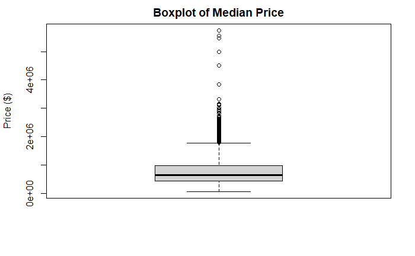

```r
# Visualise potential outliers on a boxplot
house_medians_criminal_incidents$`Median Price` %>% boxplot(main = "Boxplot of Median Price", ylab="Price ($)")
```

Looking at the boxplot of median price, there seems to be quite a number of possible outliers that sit above the 1.5 * IQR fence, indicating the possible outliers to be high house prices, with values above the $2,000,000 price.

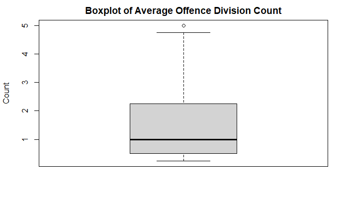

From the boxplot of average offence division count, there is only one outlier that sits above the 1.5 * IQR fence. Also indicating that the possible outlier is an average offence count of 5.

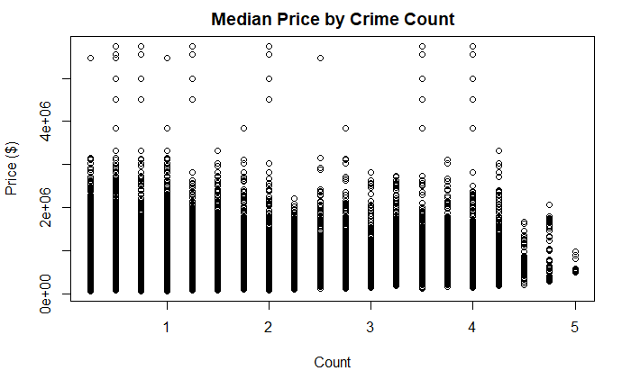

```r
house_medians_criminal_incidents %>% plot(`Median Price` ~ `Average Offence Division Count / Quarter`, data = ., ylab = "Price ($)", xlab = "Count", main = "Median Price by Crime Count")
```

As we are investigating and understanding the relationship between Average Offence Division Count and Median Price, a scatterplot is plotted to show the bivariate distribution between Average Offence Division Count and Median Price.

By observing the scatterplot, there is an indication that the possible outliers lie on the upper portion of the scatter, where house median prices are high and crime count varies. However, the scatter still seems relatively evenly scattered with most of the them clustered on the bottom half of the scatter. The upper half has significantly fewer data points but they are also relatively evenly scattered. Thus, suggesting they may not be outliers.

[output not shown]

[output cut: 26 more lines]

```r
p_outliers$Suburb %>% unique()
```

```
[1] Deepdene       East Melbourne Toorak
761 Levels: Abbotsford Aberfeldie Aintree Aireys Inlet Airport West Albanvale Albert Park Albion Alexandra ... Yinnar
```

Upon inspection of the rows where the scatter sits on the top half of the scatterplot, these values do not seem to fall under any of the common categories of outlier causes. The suburbs with a median price of over $3,500,000 are Deepdene, East Melbourne and Toorak. These few suburbs are historically known to be “posh” with grand, prestigous and established homes situated in strategic locations. Therefore, we can disregard these rows as errors caused by data entry or data processing.

In conclusion, the decision is to leave these rows within the dataframe as they will be critical for future analysis.

## **Transform**

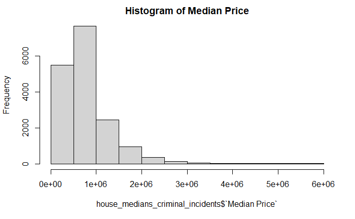

```r
hist(house_medians_criminal_incidents$`Median Price`, main = "Histogram of Median Price")
```

The distribution of Median Price is positively skewed.

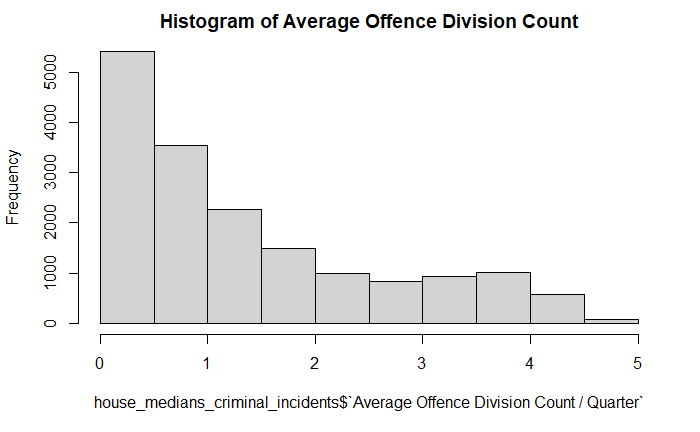

```r
hist(house_medians_criminal_incidents$`Average Offence Division Count / Quarter`, main = "Histogram of Average Offence Division Count")
```

The distribution of the Average Offence Division Count / Quarter is also positively skewed.

```r
# View portion of transformed data
transformed_house_medians_criminal_incidents$`Median Price` %>% head(10)
```

```
 [1] 24.85979 25.39082 25.00615 25.46253 24.85979 25.39082 25.00615 25.46253 24.85979 25.39082
```

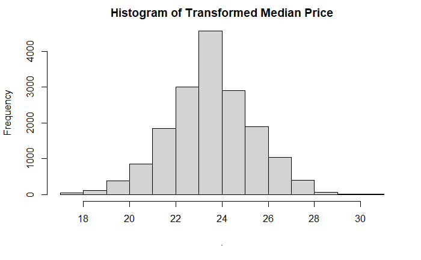

By using the BoxCox transformation, the Median Price variable was transformed from a positively skewed distribution to a symmetrical distribution.

[output not shown]

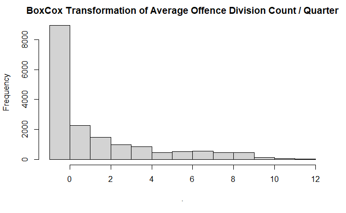

```r
# Using BoxCox transformation to transform average offence division count / quarter
BoxCox(transformed_house_medians_criminal_incidents$`Average Offence Division Count / Quarter`, lambda = "auto") %>% hist(main = "BoxCox Transformation of Average Offence Division Count / Quarter")
```

The BoxCox transformation has not been successful in transforming the average offence division count / quarter variable.

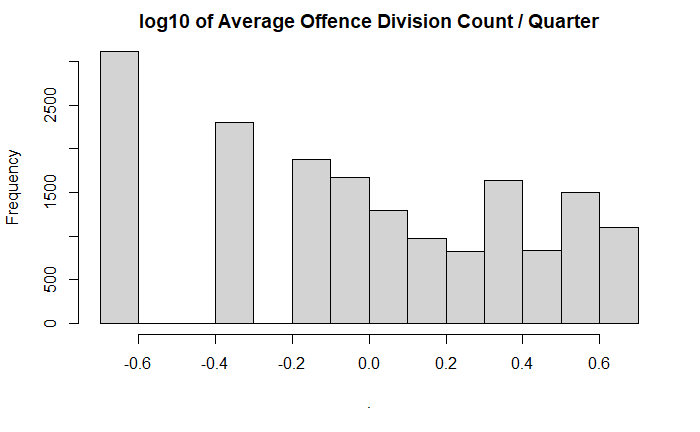

```r
# Using Log10 to transform average offence division count / quarter
log10(transformed_house_medians_criminal_incidents$`Average Offence Division Count / Quarter`) %>% hist(main = "log10 of Average Offence Division Count / Quarter")
```

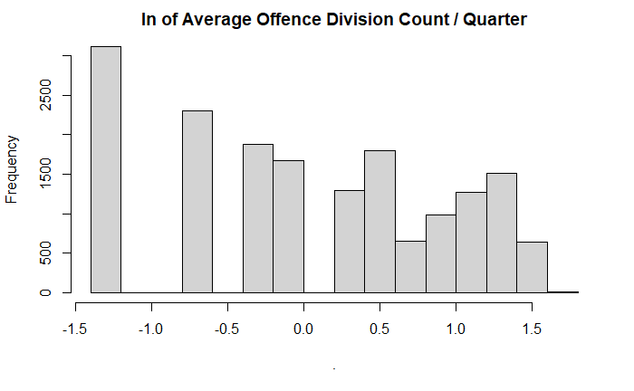

```r
# Using the natural logarithm to transform average offence division count / quarter
log(transformed_house_medians_criminal_incidents$`Average Offence Division Count / Quarter`) %>% hist(main = "ln of Average Offence Division Count / Quarter")
```

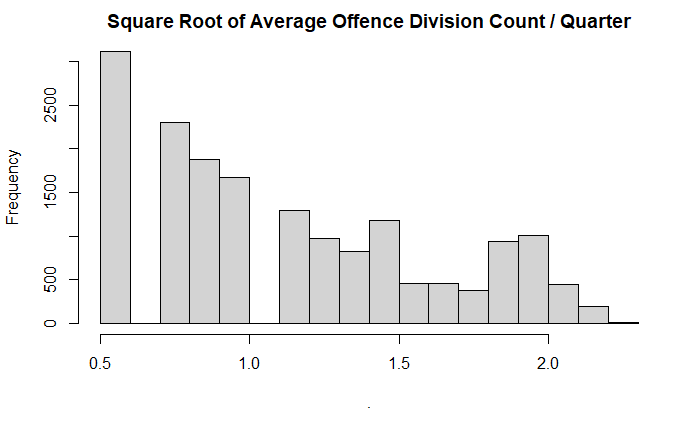

```r
sqrt(transformed_house_medians_criminal_incidents$`Average Offence Division Count / Quarter`) %>% hist(main = "Square Root of Average Offence Division Count / Quarter")
```

```r
# Assigning square root of average offence division count / quarter to an object
transformed_house_medians_criminal_incidents$`Average Offence Division Count / Quarter` <- sqrt(transformed_house_medians_criminal_incidents$`Average Offence Division Count / Quarter`)
```

```r
# View portion of transformed data
transformed_house_medians_criminal_incidents$`Average Offence Division Count / Quarter` %>% head(10)
```

[output not shown]

As the distribution of the Average Offence Division Count / Quarter is positively skewed, the BoxCox, log10, natural logarithm and square root transformations were applied on the values of the variable. After applying these transformations, none of the them yielded a perfect symmetrical distribution. However, visually, the square root transformation seems to work best on the Average Offence Division Count / Quarter variable. Hence, the square root transformation is chosen.